# Barstucks Eastern Region Sales Report

Ashley Miller

2024-12-06

# Introduction

In this report we examine calendar year 2024 sales metrics for Barstucks’ Eastern Region. The region is comprised of 20 stores given a unique id starting with store 0 and ending with store 19. Our data includes 24 sales observations for each store. One each for the food and coffee sales for the month. The food column contains a 0 or 1 depending on whether the sales from that row are coffee or food, respectively. Each store’s manager has been assigned a qualitative emotion rating that describes their level of conscientiousness and their level of neuroticism. They range from negative to positive values, indicating the degree above or below the average of each quality. Sales have been standardized to be centered at zero with a standard deviation of one. We have posed the following question: what is the effect of the stores’ manager’s emotional qualities on the sales of food and coffee, and are they different?

## Exploratory Data Analysis

The figure below shows the distribution of the values of each sales, conscientiousness (con), and neuroticism (neur). The height of each bar indicates the incidence of the feature whose value is represented by the x-axis. Note that though the figures are aligned, the y-axes scales differ. One can see how they deviate from the mean marked by the dashed black line. Notably both emotional qualities have a mean that lies below 0 (as well as outliers towards the extremes).

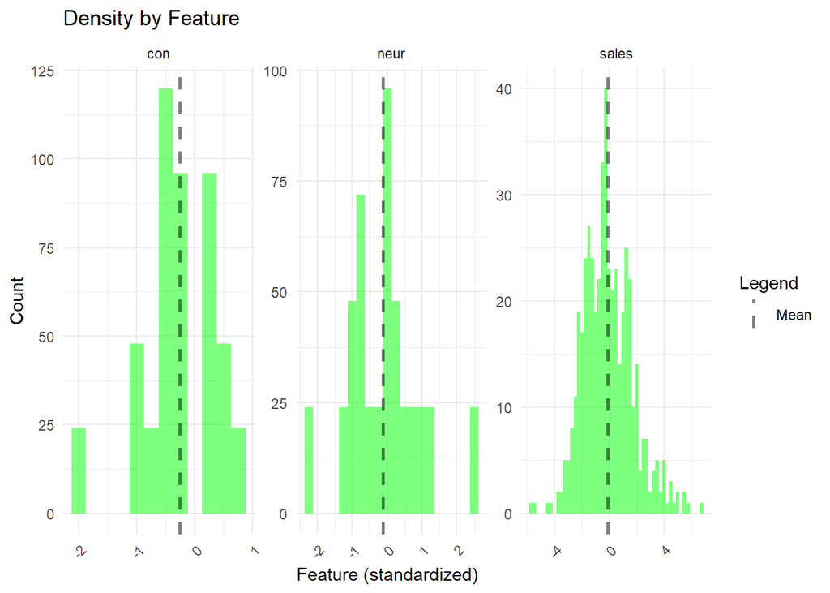

In the figures below, we further examine the emotional quality scores and sales of each store individually. The box plots show first overall sales, then the two types of sales juxtaposed.

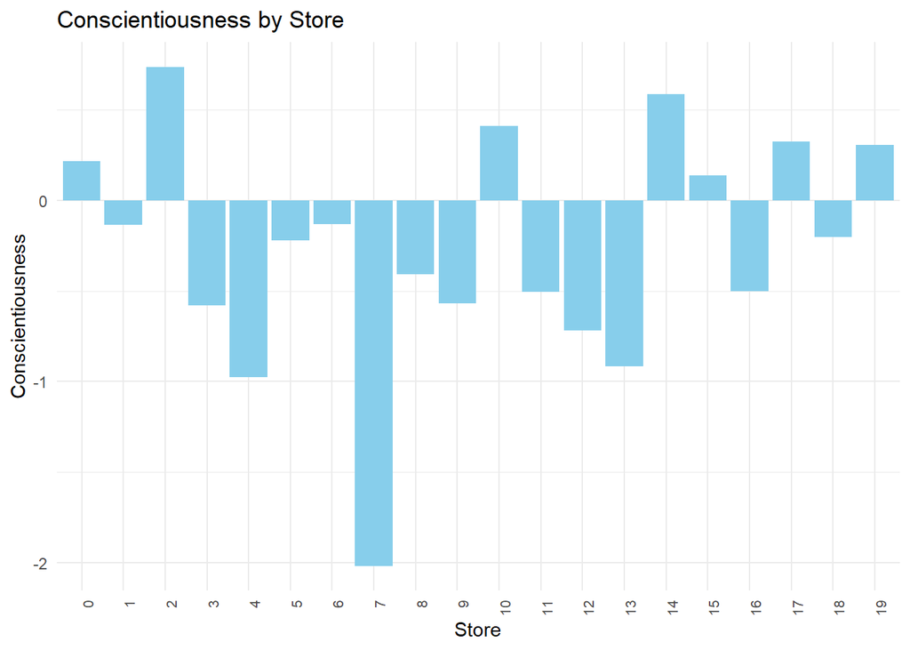

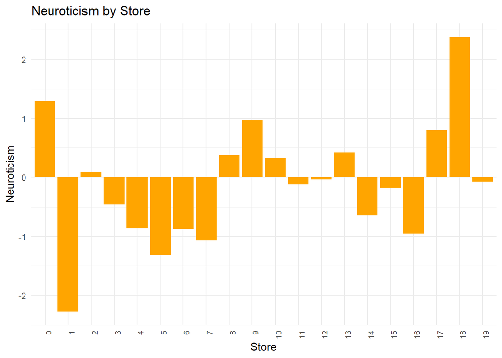

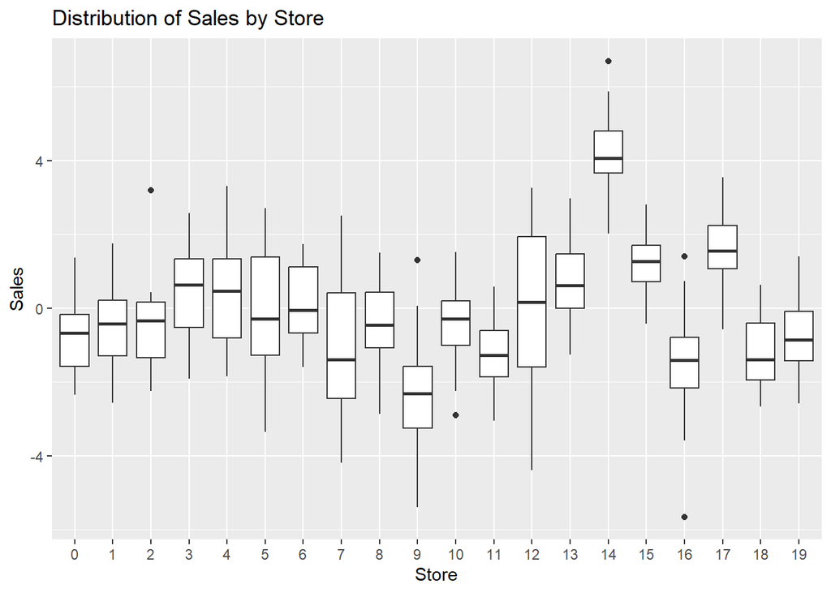

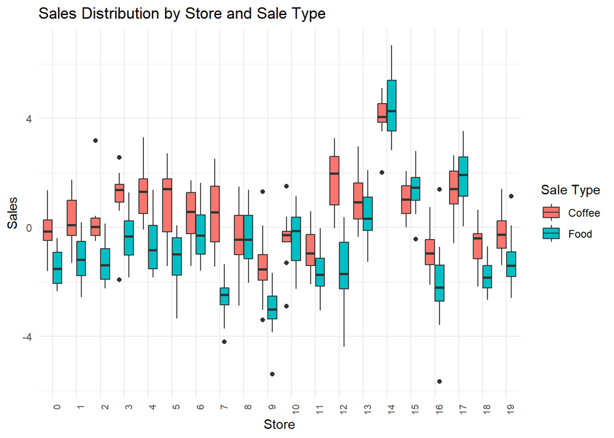

## Hierarchical Model Specification

Creating a model for these data requires an approach that accounts for the different stratifying features within the data, namely the individual stores and the dichotomy between coffee and food sales. First we want to describe our model using an equation to account for our variables and their effects.

$$\begin{aligned} \text{sales}_{ij} &
= \beta_{sales} + \beta_{con} \cdot \text{con}_{ij} + \beta_{food} \cdot
\text{food}_{i} + \beta_{con \cdot food} \cdot \text{con}_{ij} \cdot
\text{food}_{i} \\ & \quad + \beta_{neur} \cdot \text{neur}_{ij} +
\beta_{neur \cdot food} \cdot \text{neur}_{ij} \cdot \text{food}_{i} \\
& \quad + (u_{0j} + u_{1j} \cdot \text{food}_i) + \epsilon_{ij}
\end{aligned}$$
This equation specifies that the given sales for a month at a certain store is the sum of the following: the baseline coffee sales for any store, the product of the conscientiousness coefficient and conscientiousness, the food coefficient (which is nullified for sales where food is 0), the product of conscientiousness-food interaction coefficient and conscientiousness (with the same nullification), the product of the neuroticism coefficient and neuroticism, the product of neuroticism-food interaction coefficient and neuroticism (with the same nullification), the effect of the store on baseline sales, the effect of the store on food sales, and the residual error of the model. Once this is conceptualized, we can begin to specify the distributions that underly the model framework. We posit that the sales distribution overall approximates the normal distribution, and that the random effects of store and food-by-store are multivariate normal. One would argue, too, that the store and food versus coffee sales groups are minimally correlated if at all. We also specify that the errors produced by our model will be normally distributed.

The hierarchical model is then specified as follows:

$$\begin{aligned}
\text{sales}_{ij} & \sim \text{Normal}(\mu_{ij}, \sigma^2) \\
\mu_{ij} & = \beta_0 + \beta_1 \cdot \text{con}_j + \beta_2
\cdot \text{food}_i + \beta_3 \cdot \text{con}_j \cdot
\text{food}_i \\ & \quad + \beta_4 \cdot \text{neur}_j + \beta_5
\cdot \text{neur}_j \cdot \text{food}_i \\ & \quad + (u_{0j} +
u_{1j} \cdot \text{food}_i) \\ \begin{pmatrix} u_{0j} \\ u_{1j}
\end{pmatrix} & \sim \text{MVN}\left( \begin{pmatrix} 0 \\ 0
\end{pmatrix}, \Sigma \right) \\
\Sigma & = \mathbf{L} \mathbf{L}^\top \\
\epsilon_{ij} & \sim \text{Normal}(0, \sigma^2)
\end{aligned}$$
Where:
* $\text{sales}_{ij}$ denotes the outcome variable for observation $i$ in group $j$.
* $\text{con}_j$ is the conscientiousness predictor variable.
* $\text{food}_i$ is the food indicator variable.
* $\text{neur}_j$ is the neuroticism predictor variable.
* $\beta_0$ is the intercept representing baseline coffee sales
* $\beta_1, \beta_2, \beta_3, \beta_4, \beta_5$ are the coefficients for the predictors and their interactions.
* $u_{0j}, u_{1j}$ represent the group-level effects for each store.
* $\epsilon_{ij}$ is the observation-level error term.
* $\Sigma$ is the standard deviation of the group-level effects.
* $\sigma$ is the standard deviation of the observation-level errors.
* $\mathbf{L}$ is the Cholesky factor of the correlation matrix for the random effects.

The prior distributions we chose for these parameters are specified as follows:

[output not shown]

## Interpreting The Model

In the plots below, we can see the distribution of the fixed effect $\beta$ parameters, which are not dictated by the store group structure. The intercept, or $\beta_0$, is the baseline coffee sales. B_con:food and b_food:neur represent the interaction between the emotional qualities and whether the sales are food, capturing the effect of the combination of the two. This effect is an offset that affects the baseline sale amount encoded in the intercept term. The intercept (baseline sales regardless of store), conscientiousness and coffee sales, neuroticism and coffee sales and the interaction offset of neuroticism and a food-type sale have 95% quantile regions (shaded light blue) that include zero, meaning they could have a nullified effect on the sales overall (these differ from the highest probability density credible intervals above, which may be narrower depending on symmetry). The other parameters are very likely to have some effect. For the combination of conscientiousness with food-type sales, this is a positive effect. The differential for food-type sales regardless of emotional quality has a negative effect.

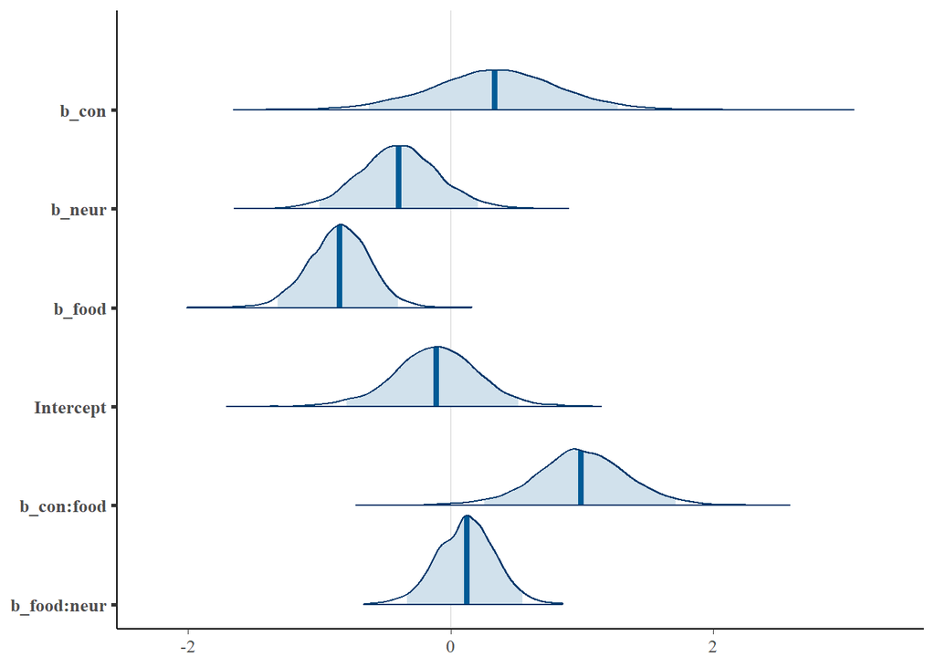

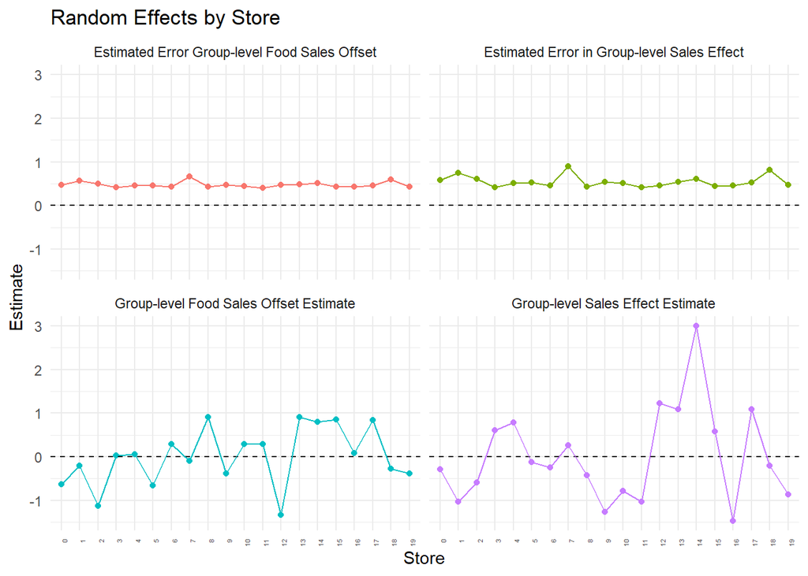

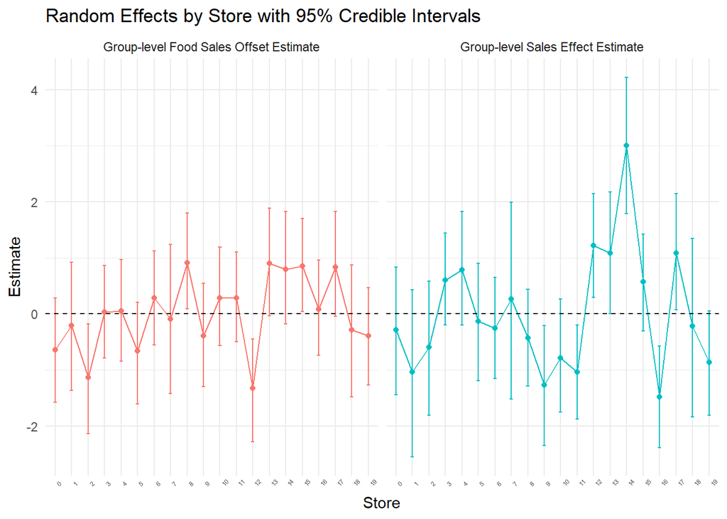

To examine the random effects even further, we can examine the posterior distributions of the random effect intercept parameter, $u_{0j}$, as a density plot. First we can place them all on the same plot to see which, if any, are set apart. We can see that store 14 seems to have higher sales than most of the other stores. The second figure breaks each store into its own plot to more easily see the individual shapes of the density plots. The dotted lines represent the mean sales across all stores.

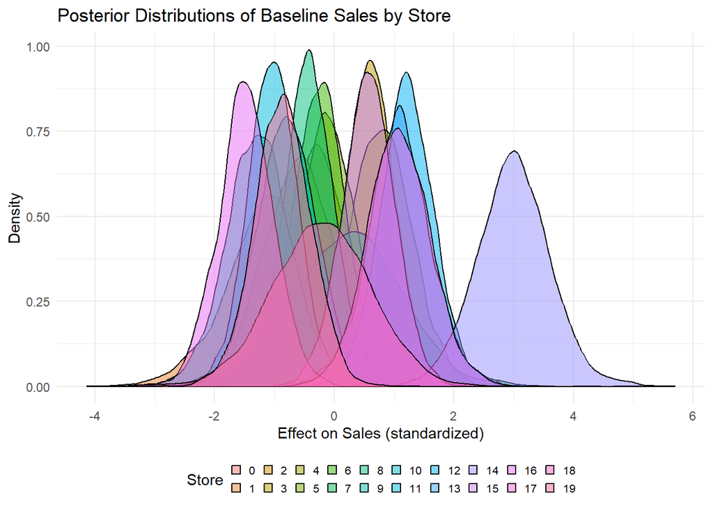

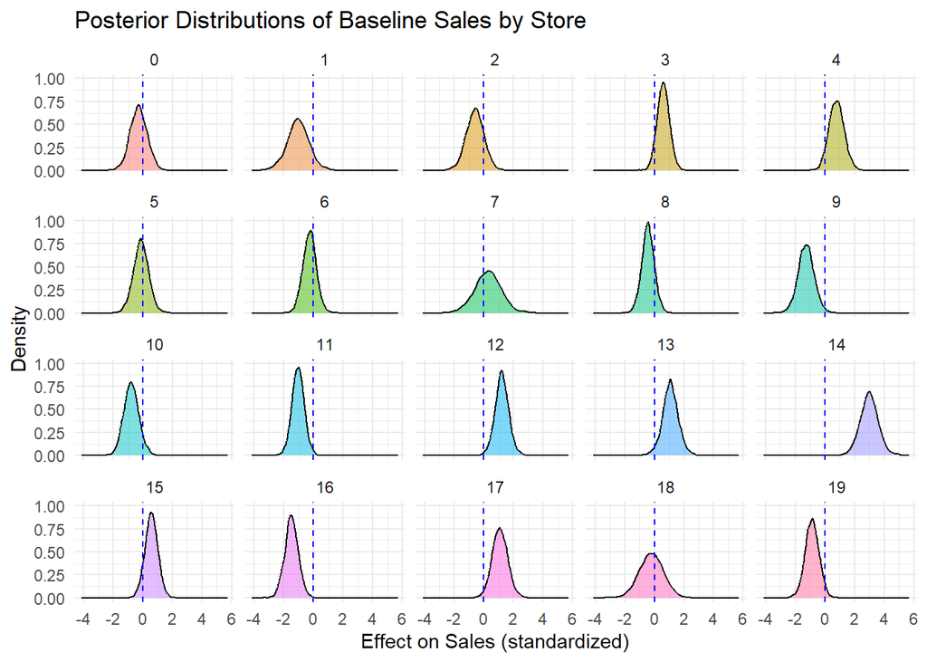

Ultimately we were tasked with determining which of the stores was overperforming after controlling for the effects of the manager’s emotional qualities. We can see from the ordered plot below that stores 14, 17, 15, and 13 are performing better than the model would estimate given that their credible intervals lie completely above the zero line.

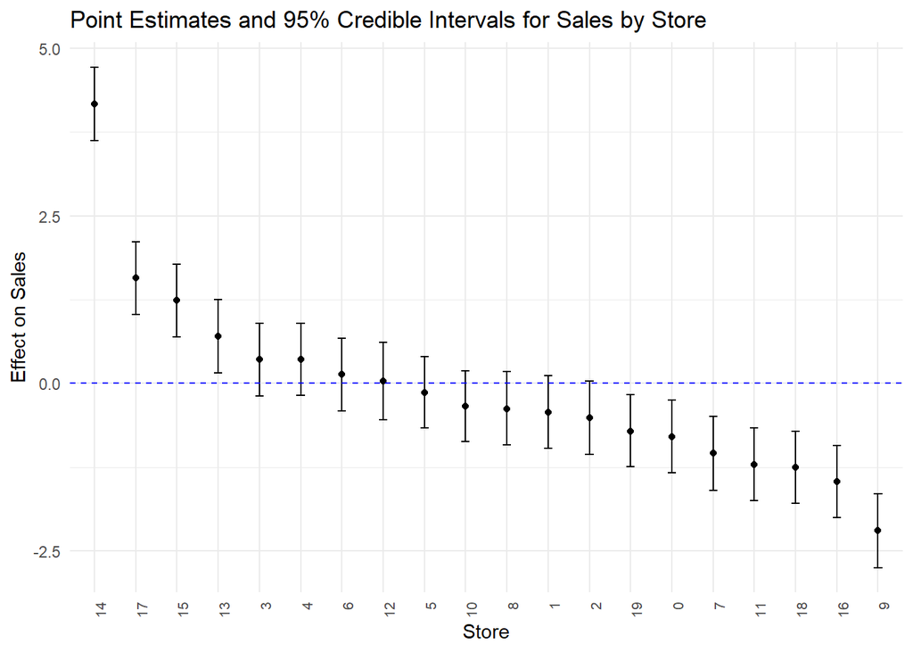

The next two sets of graphs help illustrate the effect of the emotional qualities on the sales observations for each store. There is a regression line fitted to the expected *a posteriori* (EAP) values for each store’s sales (which illustrate the most likely value) and display that with the observed sales mean and the EAP values by store. Here the center of the black diamonds represent the EAP and the grey circles represent the observed mean. The slope of the line represents the approximate effect of the emotional quality on change in sales. From the figure below, one can see that conscientiousness seems to have a positive effect on sales when the type of sale is food.

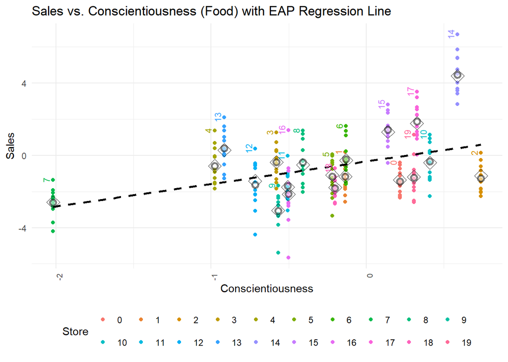

In the next figure, you can see that there is still an upward trend when the sale type is coffee, but it is less noticeable. I wanted to examine store number 12’s discrepancy between the EAP and the observed mean, so I referenced the conscientiousness values to confirm that store 12’s manager did indeed have a fairly negative score, -0.7. I would argue that score should be negatively affecting sales for store 12.

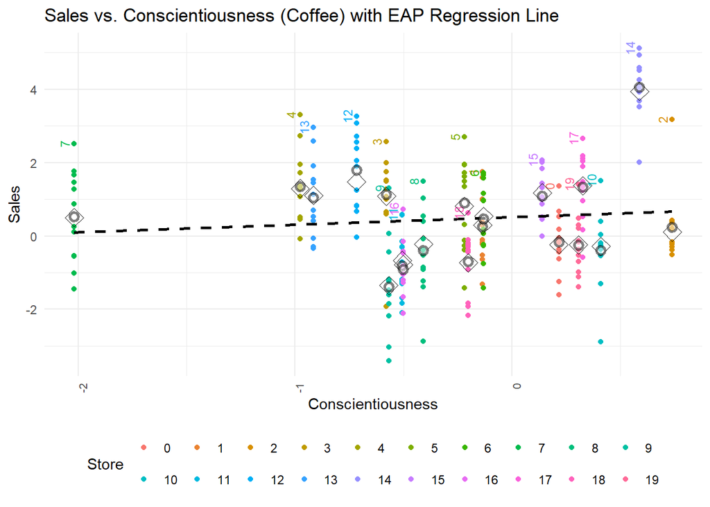

In the plot below, you can see that the trend is negative for food sales, but not as steep either.

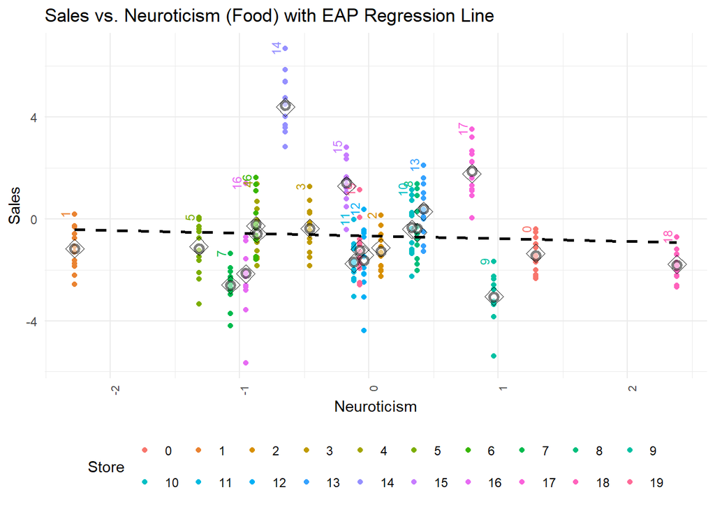

The slope for the coffee sales affected by neuroticism is a bit steeper, which implies that this may be affecting these coffee-addicted customers more negatively when faced with a manager whose neuroses are intractable. Examining store 12’s neuroticism score, we can see that a near zero value likely means that his mental illness had no effect on the sales for that year. Ultimately these results wouldn’t allow us to conclusively infer anything about the stores performance like the earlier plot of the random effect on sales (which controls for the fixed effects of our model, namely the emotional quality and the interactions between those and sales type), but they do illustrate the uncertainty inherent to our model, allowing us to ground our interpretation in reality, rather than purely relying on the model’s results.

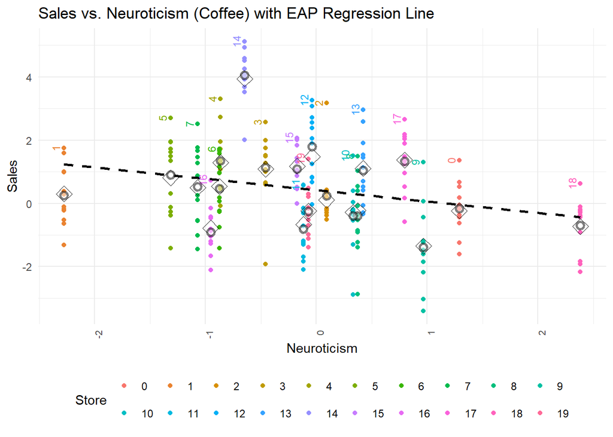

## Diagnostics

Due to the nature of this type of modeling we have included some metrics that should serve to verify the validity of the model approach. By examining the trace plots below, we can see that throughout the process of picking model parameters, there were no parameters that had a positive or negative trend and didn’t remain centered around a specific value. This would indicate a misspecification of our model.

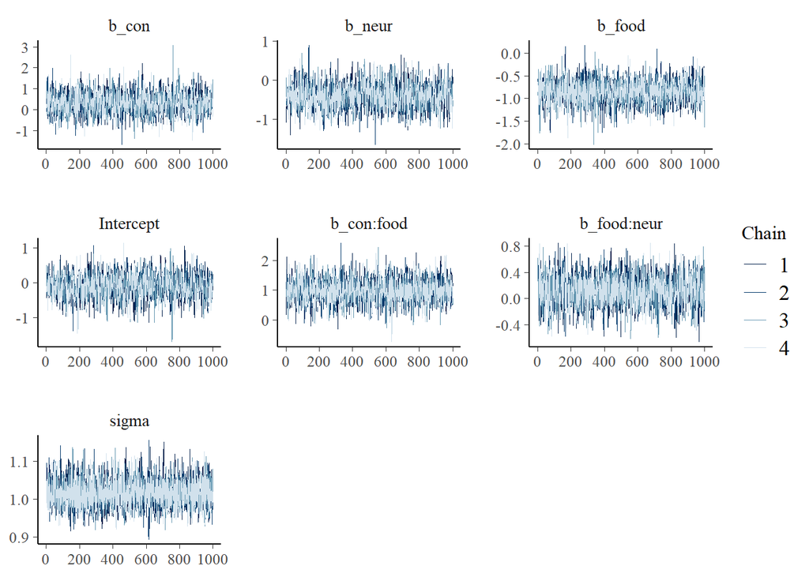

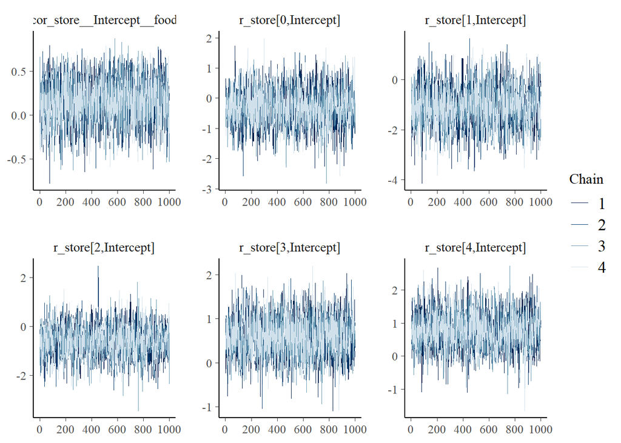

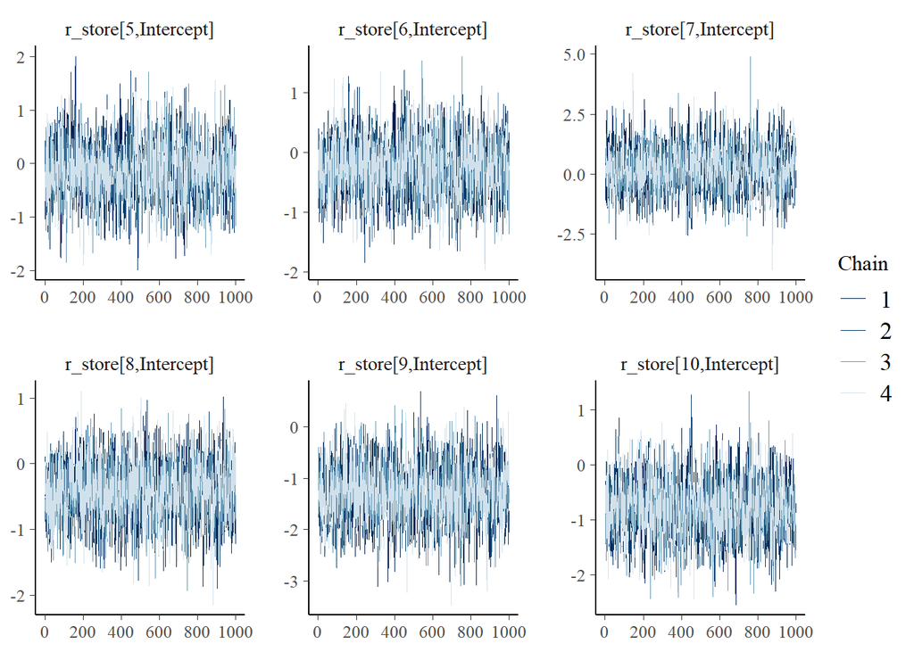

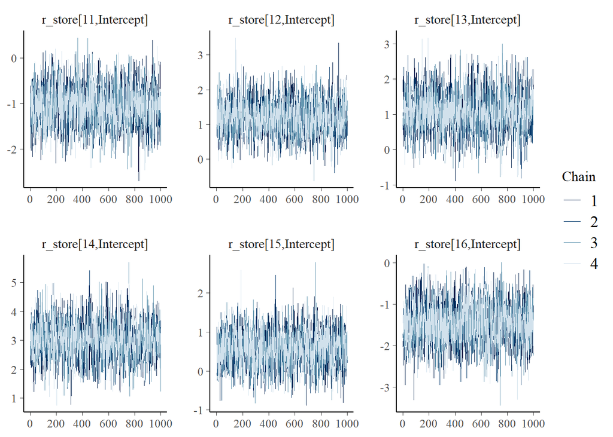

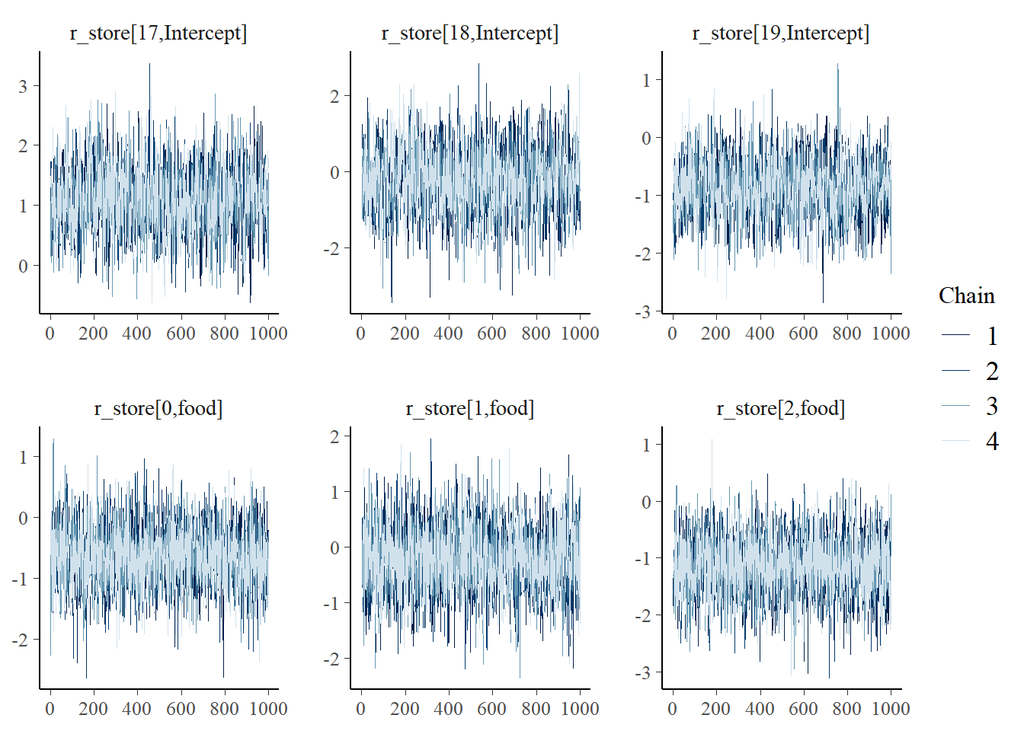

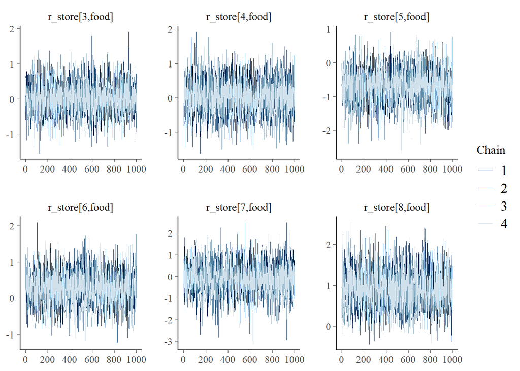

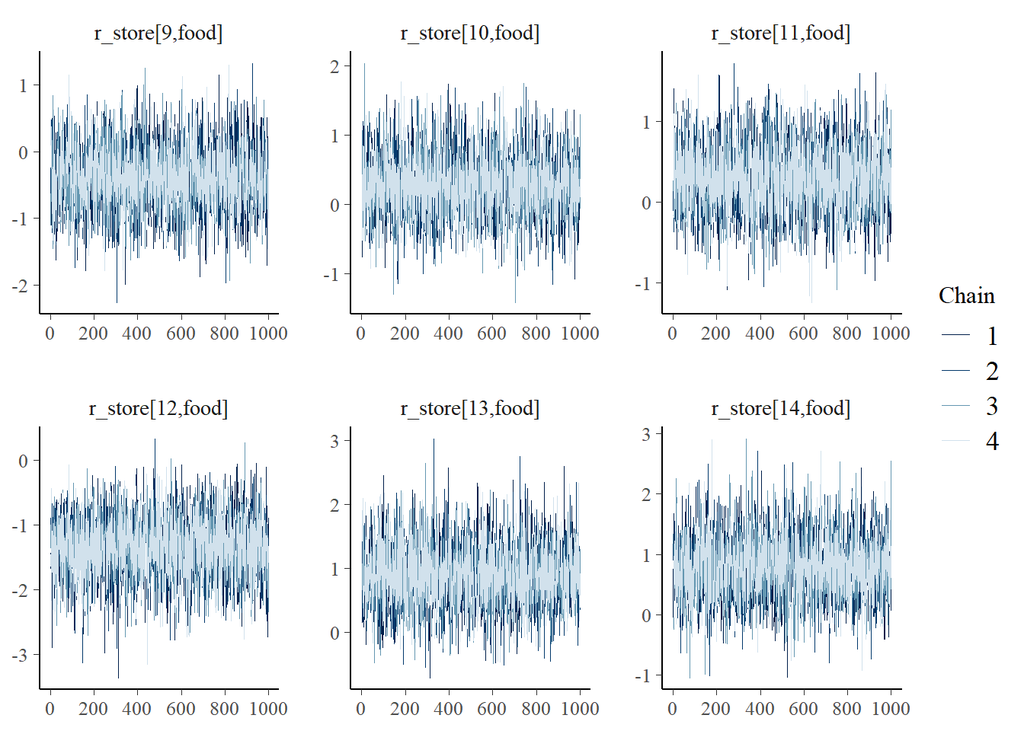

[figure not shown]

The plot below allows us to gauge the accuracy of our model to the observed outcome variable distribution. The faint lines represent the sampled distributions used by the model to arrive at its final parameter values. We don’t expect for these plots to eclipse each other, but the shape should be approximate.

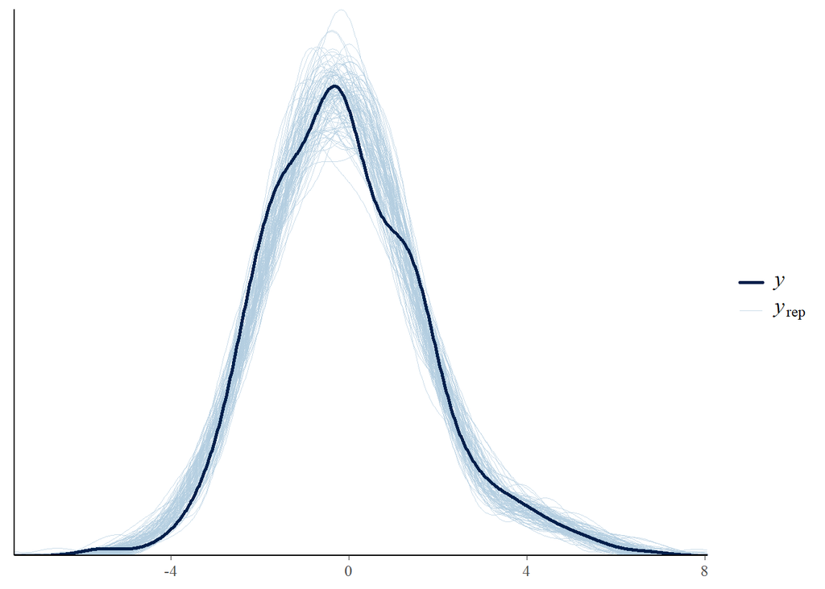

To further illustrate the fit of the model, we can examine a plot of the residuals by store to confirm that the group level effects are indeed capturing the latent effects within the data. Since the distributions are approximately similar and all the residuals are fairly centered around 0, we can argue that each group level effect is appropriate for our data.

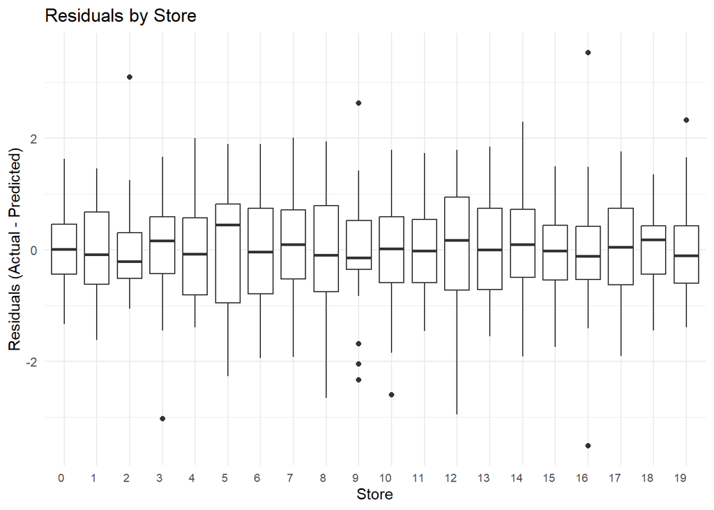